# Database Management end of Course Project SQL/ NoSQL Project

### Query 6 : Display the time of the day with the highest number of trips.

Shell

```sql
db.trips.aggregate([{ $project : { hour : { $hour : "$start time"}}}, { $group: { _id : "$hour", count:{$sum:1}}}, {$sort : { "count" : -1}}, {$limit : 1}])
```

Atlas UI  
In aggregations

#### Result

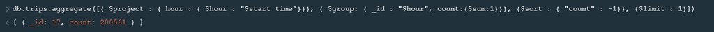

Results 6 - SHELL

#### Analysis

Our query gives us the following result: the id here represents the time slot with the highest number of trips. The analysis is therefore as follows: the time slot during which there is the greatest use of the service is between **5:00 p.m**. and **6:00 p.m**., for 200561 trips (i.e. 10% of the trips). This likely corresponds to the **end of the working day**.

#### Recommendations

The bike service must therefore be particularly vigilant during this period of time **by maximizing the number of bikes available at each station.** The service can also consider increasing its visibility for **this particular period.** For instance, offering **lower prices** for this time slot, or partnering with New York City companies to promote cycling for **work-to-home commuting.**

### Query 7 :Display trips made to end station locations with latitude values greater than 40.735238.

Shell

```sql
db.trips.find({ "end station location.coordinates.1" : { $gt: 40.735238}}).pretty()
```

Atlas UI

FILTER: {“end station location.coordinates.1” : { $gt: 40.735238}}

#### Result

[figure not shown]

Results 7 - UI

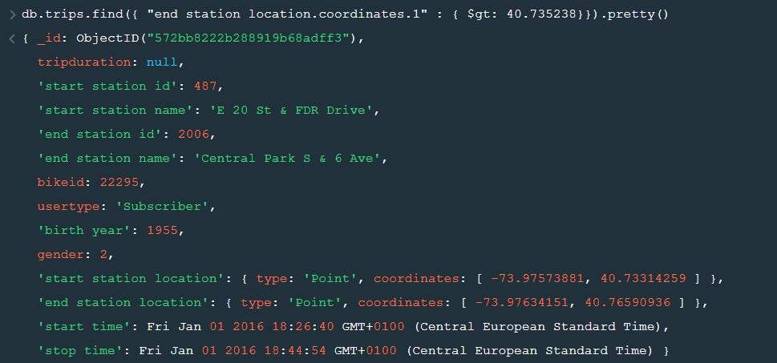

Results 7 - SHELL

#### Analysis

**1 106 649 trips** ended at a station with a latitude greater than 40.735238 i.e. more than 55% of all trips. This corresponds loosely to the neighborhoods above Brooklyn and one half of the Queens. We can analyze that there is a weak correlation between the number of inhabitants and the number of trips. Indeed, Manhattan, Queens and Bronx represent more than **2 /3 of the population** of New York and here only **half of the trips**.

### Query 8.1 : Display the most frequent circuit

Shell

```sql
db.trips.aggregate([{ $group: { _id : {start_station_name :"$start station name", end_station_name : "$end station name"}, count:{$sum:1}}}, {$sort : { count : -1 }} ])
```

#### Result

[figure not shown]

Results 8.1 - UI

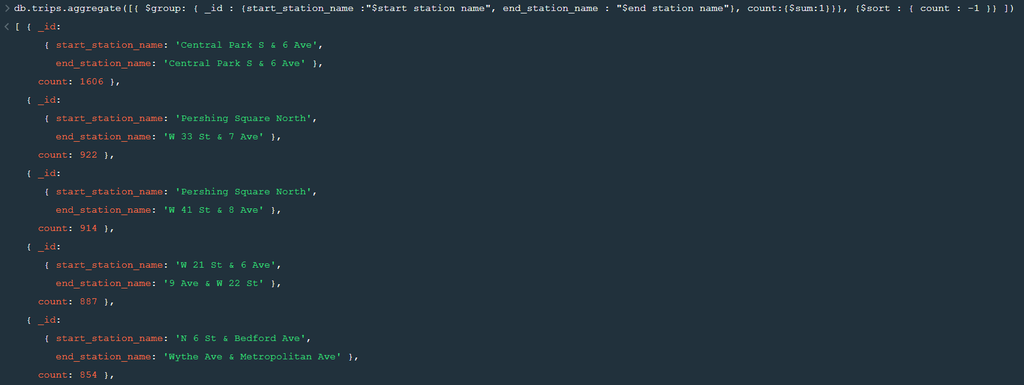

Results 8.1 - SHELL

#### Analysis

The first and most frequent circuit is around **Central Park**. Pastoral circuit, it is probably used more for leisure purposes than for commuting to and from work.  
Concerning the second most frequent circuit, we notice the departure from Pershing Square which is located in front of the **Grand Central Terminal** to go to W33 St and 7 AVE. This could concern more **newyorkers commuters**.  
In general, we notice that the bike trips cross the **major avenues** that New York knows well.

#### Recommendations

Because of the great use in Central park, it would be interesting to encourage the **installation of bike station** within and around the park. A more general recommendation here regarding the use of bicycles on **major avenues** : a special **bike lane installation** on the major avenues raised here would be a great advantage for cyclists and could reinforce its use. This could be a **priority for the mayor of New York**.

### Query 8.2 : Display the most frequent circuit according to the usertype

Shell

```sql
db.trips.aggregate([{ $group: { _id : {start_station_name :"$start station name", end_station_name : "$end station name", usertype : "$usertype"}, count:{$sum:1}}}, {$sort : { count : -1 }} ], {allowDiskUse: true})
```

#### Result

[figure not shown]

Results 8.2 - UI

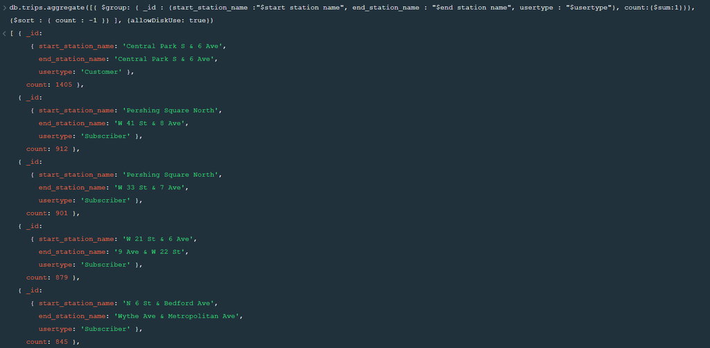

Results 8.2 - SHELL

#### Analysis

This query confirms 8.1 conclusion about Central Park circuit. We can indeed note that the circuit around Central park is mostly used by customers, either tourists or non regular users.

#### Recommendations

In order to promote the use of bicycles for tourism or leisure, New York City could promote the **advertising** of the service by tourist agencies or hotels. Propose for example **other circuit to make by bike**, **special 1-week offer, reduced prices with museums** etc…

### Query 8.3 : Display the most frequent circuit according to the hour

```sql
db.trips.aggregate([{ $group: { _id : {start_station_name :"$start station name", end_station_name : "$end station name", hour : { $hour : "$start time"}}, count:{$sum:1}}}, {$sort : { count : -1 }} ], {allowDiskUse: true})
```

#### Result

[figure not shown]

Results 8.3 - UI

[figure not shown]

Results 8.3 - SHELL

#### Analysis

From this query, we can decompose two main types of start :

First, departures from Pershing Square North and Penn Station Valet stations are close to major New York City **train stations** (respectively Central Station and Pennsylvania Station). This concerns both morning and evening departures.

Then, departures such as the one from E7 st and Avenue A. These departures are made by **the inhabitants** of the southern district of Manhattan who leave for working in the morning. Just like the departure from Broadway and 24 st, we will call these departures, **“direct departures”**. In contrast to **“indirect departures”** from bicycle stations close to train stations .

#### Recommendations

First of all, concerning indirect departures, our team would like to stress out that this is a good sign of **mutli-mobility service** : in order to relieve congestion in the city center, use public transportation for long trips and bicycles for short trips. Thus, the main aim is to **strengthen** the bicycle supply around New York City’s main **central stations** and encourage people to use bicycles for **short trips** in the city.

For **direct departures** from residential areas, such as morning departures, it is important to **reinforce** the presence of stations and available bicycles in different departure areas.

Let’s strengthen our analysis now with additional queries !

### Query B.1 : Average trip time

```sql
db.trips.aggregate([{ $group: { _id:0, tripAvg: {$avg: { $divide : [{$subtract: ["$stop time", "$start time"]}, 3600000]}}}}])
```

#### Result

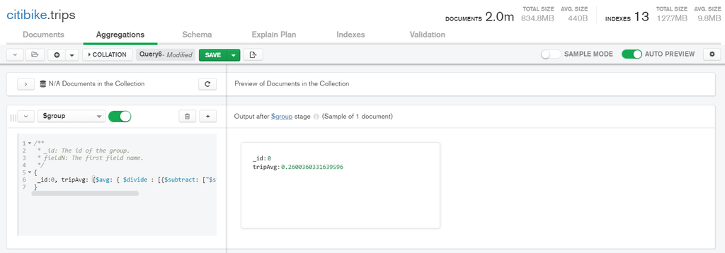

Results B.1 - UI

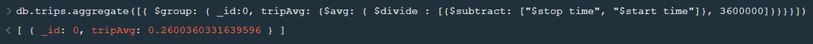

Results B.1 - SHELL

#### Analysis

The average trip time is **0.26 h i.e 15.6 minutes.** This is relatively low usage time. Indeed, compared to the average usage time of the Velib’ service used in Paris which is 36 minutes, this shows a **low use of the service.**  
If we take the average speed of 16km/h of a cyclist. This corresponds to an average distance traveled of 4 km which is **very low.**

#### Recommendations

Several recommendations :  
in addition to the increase of stations number, the price could have a **dissuasive effect** on the time of use. For instance, **offering 30 minutes of free ride** like the Velib service could have a real effect on the time of use and **thus the distance cycled in NY City.**

### Query B.2 : Display the most frequent circuit according to the gender

```sql
db.trips.aggregate([{ $group: { _id : {start_station_name :"$start station name", end_station_name : "$end station name", gender : "$gender"}, count:{$sum:1}}}, {$sort : { count : -1 }} ], {allowDiskUse: true})
```

#### Result

[figure not shown]

Results B.2 - UI

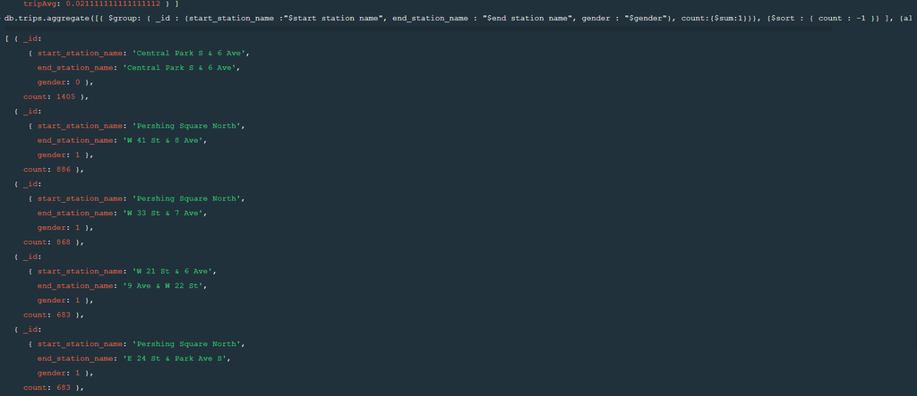

Results B.2 - SHELL

#### Analysis

For our most frequent tour, gender unknown. This seems normal at this stage: we had already analyzed that this type of circuit is mainly used by Customers (tourists or non-regular users) who are not registered in the platform and who do not inform their gender.

For the following circuits, very interesting point: the gender 1, male is **over-represented**. This could indicate an **under-use of the service by women.**

#### Recommendations

New query to do to confirm this analysis in order to count the number of women using the network. If the analysis is confirmed, the city hall must make it a priority to foster the number of women using the service.

This could be due in part to the **lack of bicycle safety in New York City**. The city should implement more **bike-friendly routes and green mobility.**

### Query B.3 : Cout by user type and by gender

```sql
db.trips.aggregate([{ $group: { _id : {usertype :"$usertype", gender : "$gender"}, count:{$sum:1}}}, {$sort : { count : -1 }} ])
```

#### Result

[figure not shown]

Results B.3 - UI

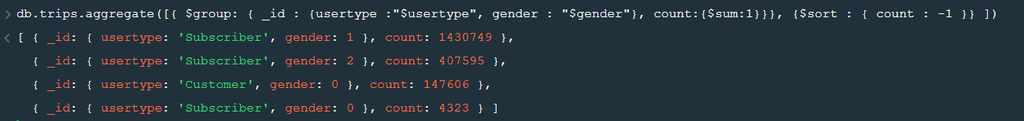

Results B.3 - SHELL

#### Analysis

The first user of the New York citibyke service is a **male subscriber to the service** (1 430 749). They represent more than **70% of the users**. The previous analysis of the **under-representation** of women is therefore confirmed here. Women, in total, account for only **20% of users**. With occasional users, they represent only **7% of the service.**

#### Recommendations

- Reinforce the safety of bicycle noise in the city.
- Create an advertising campaign to promote cycling among women.
- Strengthen bicycle tours in the city.

### Query B.4 : Average age of bikers

```sql
db.trips.aggregate([{ $match : {"birth year": {$type:"int"}}}, {$group: { _id : 0, AvgAge : {$avg : { $subtract : [ {$convert : {input : { $year : "$$NOW"}, to : "long"}}, {$convert : {input : "$birth year", to : "long"}}]}}}}])
```

#### Result

[figure not shown]

Results B.4 - UI

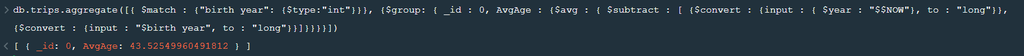

Results B.4 - SHELL

#### Analysis

The average age is **43**. Our average user of the service is therefore a 43-year-old male subscriber to the service.

### Query B.5 : How many bikes have been used ?

```sql
db.trips.distinct( "bikeid" ).length
```

#### Result

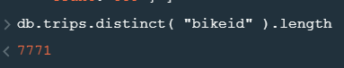

Results B.5 - SHELL

#### Analysis

In total, over the period studied, **7 771 bicycles were used**. For 1 990 273 trips, everything else being equal, this represents a rate of use per bike of **256 trips** per bike during the 3 month-period or **3 trips per bike per day.**

#### Recommendations

Although this utilization rate per bike appears to be quite low, our analytic team recommends to the city council **not to give** into the pressure to **reduce the number of available bicycles.** On the contrary, the **more bikes available** (and particularly at the hot spots identified above), the time of usage and therefore the higher the rate of use per bike.

### Query B.6 : From how many stations ?

```sql
db.trips.distinct( "start station id" ).length
```

cf Results below.

### Query B.7 : To how many stations ?

```sql
db.trips.distinct( "end station id" ).length
```

#### Result

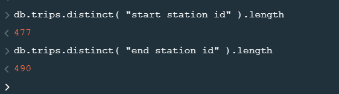

Results B.7 -SHELL

#### Analysis

We must be careful in our analysis. There are no more stations on one side than on the other since there is a fixed number of stations.

This request, however, gives us the following information: **there is more point of arrival than point of departure in the use of the service.**

In other words, cyclists leave more **from the same place** (probably from places close to railway stations) and **disperse more on arrival** (probably to go home, to work or to their meeting point).

#### Recommendations

This confirms the use of the service identified above for work - home commuters and reinforces our team’s recommendation to promote the **multi-mobility of users** (departures from major stations) to workplaces in the city. This, notably by promoting **the more dispersed installation** of bicycle stations in the city.

### Query B.8 : What is the day Of Week with the biggest number of trips ?

```sql
db.trips.aggregate([{ $group: { _id : {day : { $dayOfWeek : "$start time"}}, count:{$sum:1}}}, {$sort : { count : -1 }} ])
```

#### Result

[figure not shown]

Results B.8 - UI

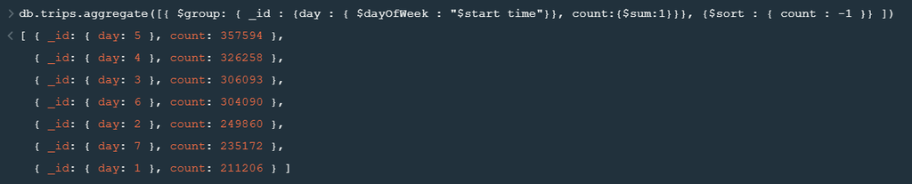

Results B.8 -SHELL

#### Analysis

For weekends, we can see a low number of users, which reflects low usage outside of commuting.

#### Recommendations

For the first point, one recommendation would be to install **more electric bicycles**. Indeed, perhaps installing more of this type of bike would encourage users to use it every day, having more confidence in this means of transportation in terms of the time needed for their trip or because it would require less energy in the morning or when returning home in the evening.

As for the second point, it seems clear now that New York City should encourage **more cycling outside the home-work circuits**.

Thank you for reading !